# Space-Time Prediction of Bike Share Demand

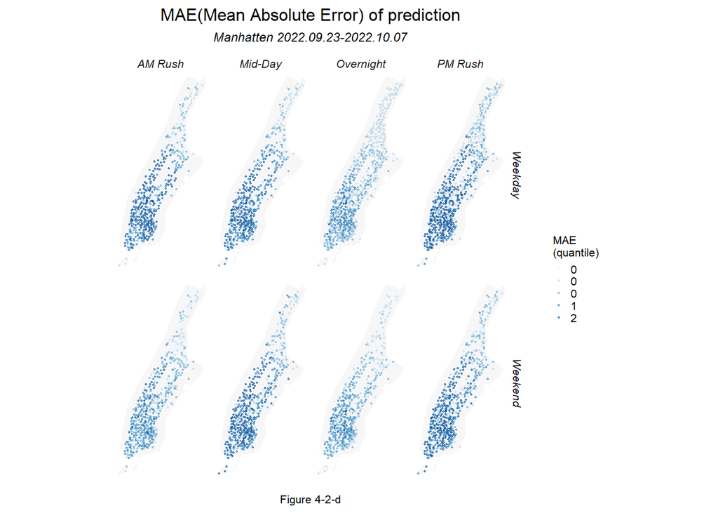

```r
##--------------------Space-Time regression model prediction-----------------------------##

week_predictions_D <- week_predictions %>%
  mutate(interval60 = map(data, pull, interval60),
         start_station_id = map(data, pull, start_station_id),
         start_lat = map(data, pull, start_lat),
         start_lng = map(data, pull, start_lng),
         dotw = map(data, pull, dotw) ) %>%
  dplyr::select(interval60, start_station_id, start_lng,
         start_lat, Observed, Prediction, Regression,
         dotw) %>%
  unnest() %>%
  filter(Regression == "DTime_Space_FE_timeLags")%>%
  mutate(weekend = ifelse(dotw %in% c("토", "일"), "Weekend", "Weekday"),
       time_of_day = case_when(hour(interval60) < 7 | hour(interval60) > 19 ~ "Overnight",
                               hour(interval60) >= 7 & hour(interval60) < 10 ~ "AM Rush",
                               hour(interval60) >= 10 & hour(interval60) < 15 ~ "Mid-Day",
                               hour(interval60) >= 15 & hour(interval60) <= 19 ~ "PM Rush")) %>%
  group_by(start_station_id, weekend, time_of_day, start_lng, start_lat) %>%
  summarize(MAE = mean(abs(Observed-Prediction), na.rm = TRUE)) %>% st_as_sf(., coords = c("start_lng", "start_lat"), crs = 'EPSG:2263')


ggplot()+
  geom_sf(data = NewyorkTracts, fill = greyPalette5[1], color = "transparent")+
  geom_sf(data = week_predictions_D, aes(color = q5(MAE)), alpha = 0.6, size = 0.3) +
  scale_colour_manual(values = bluePalette5, labels=qBr(week_predictions_D,"MAE"), name="MAE\n(quantile)")+
  ylim(min(Bike_trip_data_20220903_20221007_tracts$start_lat), max(Bike_trip_data_20220903_20221007_tracts$start_lat))+
  xlim(min(Bike_trip_data_20220903_20221007_tracts$start_lng), max(Bike_trip_data_20220903_20221007_tracts$start_lng))+
  facet_grid(weekend ~ time_of_day)+
  labs(title="MAE(Mean Absolute Error) of prediction",
       subtitle="Manhatten 2022.09.23-2022.10.07",
       caption = "Figure 4-2-d")+
  mapThememin()+
  theme(panel.background = element_blank(),
        legend.key.size = unit(0.3, "cm"),
        legend.key = element_rect(colour = NA, fill = NA))
```

### 4-3. Cross validation

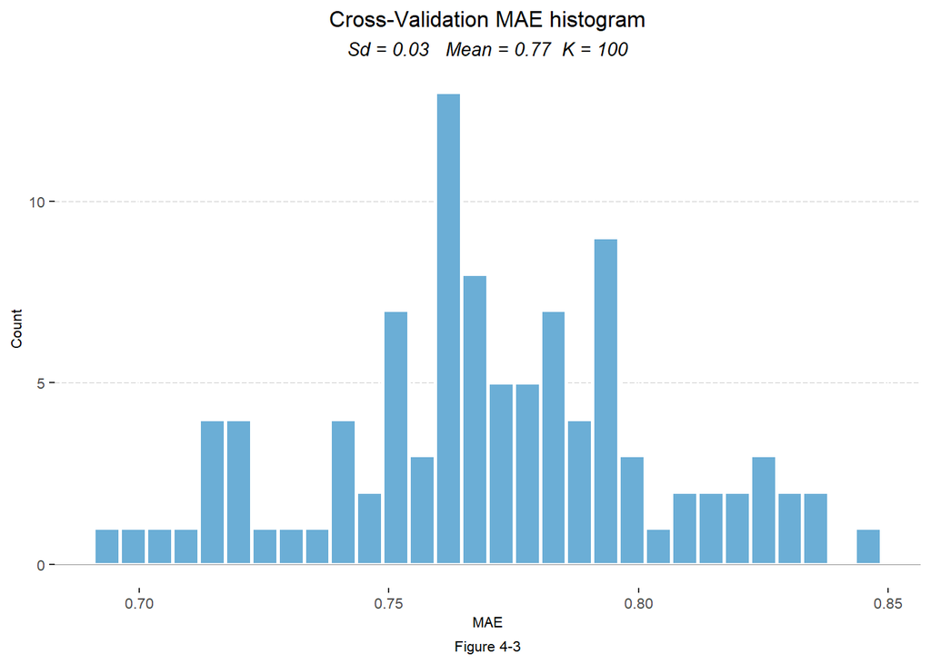

```r
##--------------------Space-Time regression model prediction-----------------------------##


ride.panel_sample <- sample_n(ride.panel, 100000) %>% na.omit()

fitControl <- trainControl(method = "cv", number = 100)

set.seed(123)

reg.cv <- train(Trip_Count ~ ., data = ride.panel_sample %>% dplyr::select(Trip_Count, start_station_name, hour, dotw, Temperature,  Precipitation, lagHour,
                                                                    lag2Hours, lag3Hours, lag12Hours, lag1day),
                method = "lm", trControl = fitControl, na.action = na.pass)


MAE.cv = data.table(MAE.cv= reg.cv$resample[,3])


MAE.sd <- as.character(round(sd(reg.cv$resample[,3]),2))
MAE.mean <- as.character(round(mean(reg.cv$resample[,3]),2))

caption <- paste("Sd =",MAE.sd, "  Mean =",MAE.mean, " K = 100")

ggplot(MAE.cv, aes(x = MAE.cv))+
  geom_histogram(fill=bluePalette5[3], color = "white", size = 1)+
  geom_hline(yintercept = 0, size = 0.25, color = greyPalette5[3]) +
  labs(title = "Cross-Validation MAE histogram",
       subtitle = caption,
       x="MAE",
       y="Count",
       caption = "Figure 4-3") +
      corTheme2()+
  theme(panel.background = element_blank(),
        panel.grid.major.y = element_line(linetype = "longdash", size = 0.25, color = greyPalette5[2]))
```

# 5. Conclusion

The purpose of this study is to accurately predict the demand for bicycles at specific stops at specific times. Although the study is limited to 5 weeks, it has shown good results in terms of Accuracy. However, considering the fact that most of the problems with shared bicycles that occur in reality are during peak hours, and there is a part that needs to be improved in that most inaccurate predictions occurred during peak hours. Applying a time weight for peak hours or reducing the combined bike usage data to 15 minutes per hour will improve the accuracy of the forecast and improve the accuracy of the peak area. In addition, in order to improve the accuracy of this study, it is necessary to adopt empirical knowledge of human resources directly intervening in actual bicycle operations. Given the current trend of bicycle usage, there are significantly less-used stops, and if you check the actual field opinion on this part and exclude the stops judged as Outliers from the analysis, this will also be a good way to improve the model.